# Chapter 2 HW

Ulices Gonzalez

Febuary 13th, 2025

#### Exercise 2: Explain whether each scenario is a classifcation or regression problem, and indicate whether we are most interested in inference or prediction. Finally, provide n and p.

1. We collect a set of data on the top 500 firms in the US. For each firm we record profit, number of employees, industry and the CEO salary. We are interested in understanding which factors affect CEO salary.

Regression - This would be a regression as we are looking at numerical values such as profit and number of employees, infer the factors that affect the salary of the CEO.  
Inference - Using these values indicates that there is interest in coming up with an inference using the data.  
n = 500 ; p = 3;

2. We are considering launching a new product and wish to know whether it will be a success or a failure. We collect data on 20 similar products that were previously launched. For each product we have recorded whether it was a success or failure, price charged for the product, marketing budget, competition price, and ten other variables.

Classification - Since it is mentioned that the purpose of the collection of data being used to determine if a product will be a success or a failure it would mean that this would be a classification.  
Prediction - This would then mean that the data collected would be used to provide a prediction for this classification.  
n = 20; p = 13;

3. We are interested in predicting the % change in the USD/Euro exchange rate in relation to the weekly changes in the world stock markets. Hence we collect weekly data for all of 2012. For each week we record the % change in the USD/Euro, the % change in the US market, the % change in the British market, and the % change in the German market.

Regression - For this last problem due to the use of numerical values to make a predication in the % change of the USD/Euro Exchange rate this problem would be a regression problem.  
Prediction - It is also explained to us that the intention of the problem is to come up with a prediction.  
n = 52; p = 3;

#### Exercise 4: You will now think of some real-life applications for statistical learning.

1. Describe three real-life applications in which classification might be useful. Describe the response, as well as the predictors. Is the goal of each application inference or prediction? Explain your answer.

Garbage Day Pickup  
Response - Will the garbage be picked up?  
Predictors - Day of the Week, Time of Day, Is it a Holiday?  
Goal - To infer if your Garbage will picked up.  
If it is a holiday typically garbage is not picked up so if it is not a holiday you can consider whether it is the assigned day of the week for pick up along with the time of the day as it will usually only be done form the morning to early afternoon but not after.

Tax Filing Eligibility  
Response - Can I file my taxes?  
Predictors - W2 has been issued, Tax Appointment Scheduled, Online Tax Process Started, Has 4/15 passed?  
Goal - To infer whether you are able to file your taxes either online or in person.  
Almost every year your taxes need to be filed by the 15th of April or whichever day is set for the year. If the day has not passed then you can file your taxes only if you have your W2 and from there you either need to have an appointment set up or the process started online. Otherwise you wouldn’t be able to file your taxes.

Incoming Paycheck/Direct Deposit  
Response - Am I going to get paid?  
Predictors - Timecard Submission, Check/Deposit Received, Has it been two weeks since last check/deposit?  
Goal - To predict whether your Check/Deposit has been recieved or is in process.  
For most employees their payment is set up biweekly either for them to recieve a check or a deposit in their bank account. If your timecard has been submitted for the last pay period and its been two weeks or more either your payment is in process or it has already been receieved.

2. Describe three real-life applications in which regression might be useful. Describe the response, as well as the predictors. Is the goal of each application inference or prediction? Explain your answer.

Temperature Forecast for a Given Day  
Response - What will be the highest and lowest temperature during the day?  
Predictors - Last Week’s Highest/Lowest Daily Temperatures, High/Low from same day year before  
Weather and temperature forecasts can change regularly but by using the highs and lows from the past 7 days you can predict probable highs and lows of the current day or the next using the average taken. This can then be verified by looking at the temperature on the same day the year before to predict a probable range.

Car Resale Value  
Response - How much can a car sell for?  
Predictors - Car Age, Mileage, Previous Owner(s), Fuel Efficiency, Make/Model, Condition, Prior Accidents  
Goal - To infer the future resell value of a car.  
Overtime a car can depreciate in value depending based on different factors, if a car has low fuel efficiency yet has high mileage if it is a recent car then its likely to have a lower resale value than a car with better fuel efficiency and mileage. The car manufacturer and type come also can affect this value either positively or negative. Lastly if there is a history of accidents or many prior owners this could negatively impact the resale value. When considered altogether it is then possible to infer the resale value of a car.

Life Insurance Policy Value  
Response - What will the value of a life insurance policy be?  
Predictors - Age, Medical History, Lifestyle  
Goal - To infer total value of a customers life insurance policy.  
When someone applies for a life insurance policy insurance agents often will ask questions regarding the customers health. One’s medical history can lead to a lower or higher value depending on what is found. Lifestyle choices are also taken into account as someones weight, history of drinking and or smoking can lead to health issues down the line that may decrease the value of the policy. Lastly the younger a customer is the higher their potential policy value will be so long as their medical history and lifestyle are not high risk. Using these it is possible for both customers and agents to infer the value of a given policy before anything is set.

3. Describe three real-life applications in which cluster analysis might be useful.

Diet Preferences  
If a restaraunt is trying to develop a new menu they can group customers based off what their meals of choice are when they come in. It allows for customers to be grouped based on if they eat meat, if they’re pescatarian, vegetarian, vegan, and other dietary preferences. This then allows a restaraunt owner to revamp their menu or make a new one altogether with new options that fit each group or cluster.

Book Club Selections  
Typically a book club will sit down and select a single book to be the focus of their meeting but because of how diverse the tastes are from each participant creating clusters based on preferred genre can allow for smaller discussions to be part of a book club if they could not come to a final say on a single book. This would allow the hosts of the book club to set out different groups such as science fiction, mystery, western, biography, and many other options that can be used. This allows everyone to participate while also making it easier in cases where some didnt have access or just didnt read a single book.

Museum Tour Groups  
Depending on the museum you may got to there will be a lot of variety when it comes to the exhibits present. In cases where guests have a preference on the tour and exhibits they take you can cluster them based off a giving focus. An example of this would be the legion of honor in the city, they have classical paintings, contemporary, sculptures, photpgrahy and much more. Clusters like these would make it easier for field trips, family excursions, and other activities to suit the preferences of people in the museum while also filling the capacity for a given tour.

## Applied Questions

#### Exercise 8: This exercise relates to the College data set. It contains a number of variables for 777 different universities and colleges in the US.

```r
college <- read.csv("DataSets/College.csv")
```

```r
rownames(college) <- college[, 1]
View(college)

college <- college[, -1]
View(college)
```

```r
summary(college)
```

```
##    Private               Apps           Accept          Enroll
##  Length:777         Min.   :   81   Min.   :   72   Min.   :  35
##  Class :character   1st Qu.:  776   1st Qu.:  604   1st Qu.: 242
##  Mode  :character   Median : 1558   Median : 1110   Median : 434
##                     Mean   : 3002   Mean   : 2019   Mean   : 780
##                     3rd Qu.: 3624   3rd Qu.: 2424   3rd Qu.: 902
##                     Max.   :48094   Max.   :26330   Max.   :6392
##    Top10perc       Top25perc      F.Undergrad     P.Undergrad
##  Min.   : 1.00   Min.   :  9.0   Min.   :  139   Min.   :    1.0
##  1st Qu.:15.00   1st Qu.: 41.0   1st Qu.:  992   1st Qu.:   95.0
##  Median :23.00   Median : 54.0   Median : 1707   Median :  353.0
##  Mean   :27.56   Mean   : 55.8   Mean   : 3700   Mean   :  855.3
##  3rd Qu.:35.00   3rd Qu.: 69.0   3rd Qu.: 4005   3rd Qu.:  967.0
##  Max.   :96.00   Max.   :100.0   Max.   :31643   Max.   :21836.0
##     Outstate       Room.Board       Books           Personal
##  Min.   : 2340   Min.   :1780   Min.   :  96.0   Min.   : 250
##  1st Qu.: 7320   1st Qu.:3597   1st Qu.: 470.0   1st Qu.: 850
##  Median : 9990   Median :4200   Median : 500.0   Median :1200
##  Mean   :10441   Mean   :4358   Mean   : 549.4   Mean   :1341
##  3rd Qu.:12925   3rd Qu.:5050   3rd Qu.: 600.0   3rd Qu.:1700
##  Max.   :21700   Max.   :8124   Max.   :2340.0   Max.   :6800
##       PhD            Terminal       S.F.Ratio      perc.alumni
##  Min.   :  8.00   Min.   : 24.0   Min.   : 2.50   Min.   : 0.00
##  1st Qu.: 62.00   1st Qu.: 71.0   1st Qu.:11.50   1st Qu.:13.00
##  Median : 75.00   Median : 82.0   Median :13.60   Median :21.00
##  Mean   : 72.66   Mean   : 79.7   Mean   :14.09   Mean   :22.74
##  3rd Qu.: 85.00   3rd Qu.: 92.0   3rd Qu.:16.50   3rd Qu.:31.00
##  Max.   :103.00   Max.   :100.0   Max.   :39.80   Max.   :64.00
##      Expend        Grad.Rate
##  Min.   : 3186   Min.   : 10.00
##  1st Qu.: 6751   1st Qu.: 53.00
##  Median : 8377   Median : 65.00
##  Mean   : 9660   Mean   : 65.46
##  3rd Qu.:10830   3rd Qu.: 78.00
##  Max.   :56233   Max.   :118.00
```

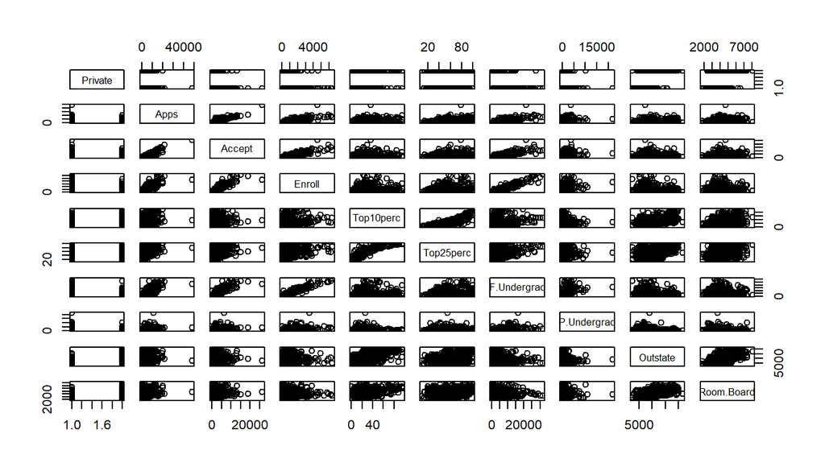

```r
college$Private <- as.factor(college$Private)
pairs(college[, 1:10])
```

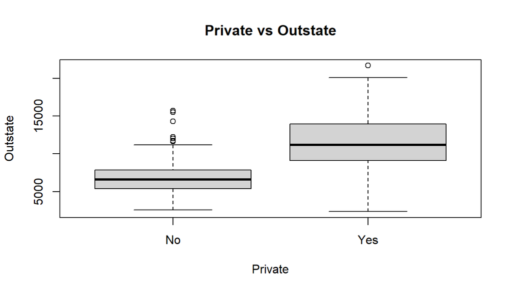

```r
plot(college$Private, college$Outstate, xlab = "Private", ylab = "Outstate", main = "Private vs Outstate")
```

```r
Elite <- rep("No", nrow(college))
Elite[college$Top10perc > 50] <- "Yes"
Elite <- as.factor(Elite)
college <- data.frame(college, Elite)

summary(Elite)
```

```
##  No Yes
## 699  78
```

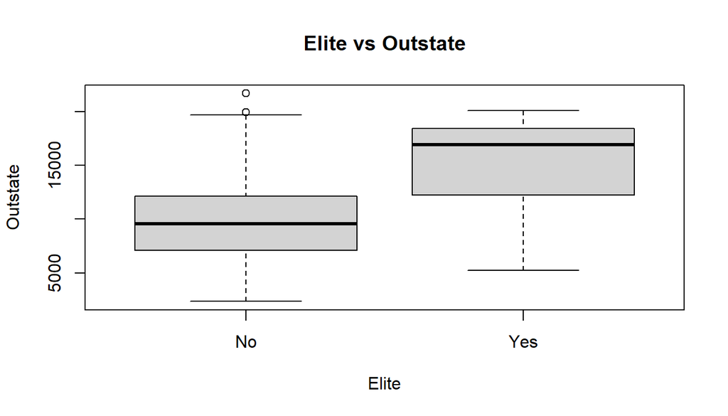

```r
plot(Elite, college$Outstate, xlab = "Elite", ylab = "Outstate", main = "Elite vs Outstate")
```

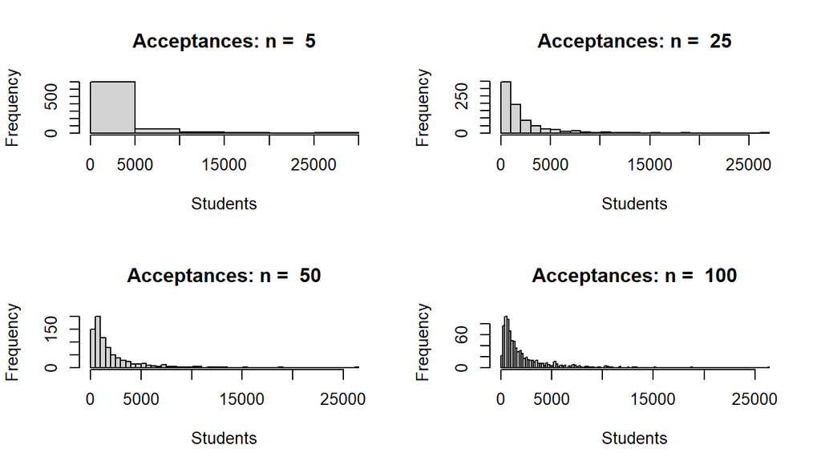

```r
par(mfrow = c(2, 2))
for (n in c(5, 25, 50, 100))
{
  hist(college$Accept, breaks = n, xlab = "Students", main = paste("Acceptances: n = ", n))
}
```

6. Based on the given data majority of schools included are Private. Looking at the acceptances there seems to be more students enrolled at a given time if total enrollments for a university are between 0 to 5000 students but skews towards higher acceptance rates towards 0 to 1250 approx. As the number of student grows there is a decline in acceptances amongst all universities in the dataset.

#### Exercise 10: This exercise involves the Boston housing data set.

```r
library(ISLR2)
```

The data set contains 506 rows which represent Suburbs of Boston and has 13 columns which represent variables such as number of rooms, median value, and per capita crime rate for example.

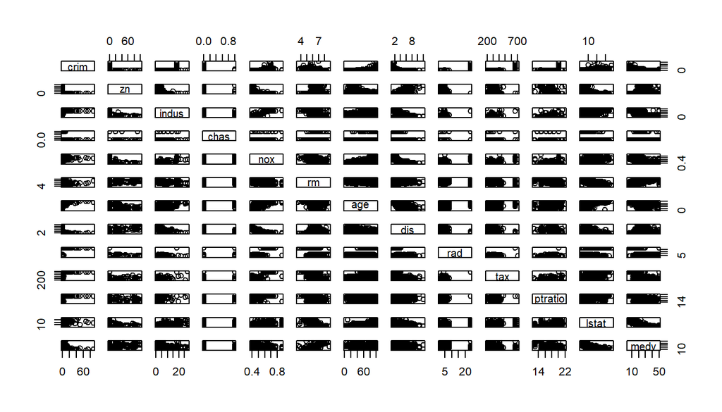

```r
pairs(Boston)
```

The relationship with the Charles River Dummy Variable is shown to have a constant relationship throughout the data set which makes sense since it can either be 0 or 1 but instead of varying significantly in its relationship with the rest of the variables almost all the graphs show the same relationship.

3. Looking at the scatterplots there seems to be an increase in crime per capita the older the neighborhood is. A similar relationship is seen with higher access to highways, higher tax rate, and higher pt ratio correlating with a higher crime per capita rate.

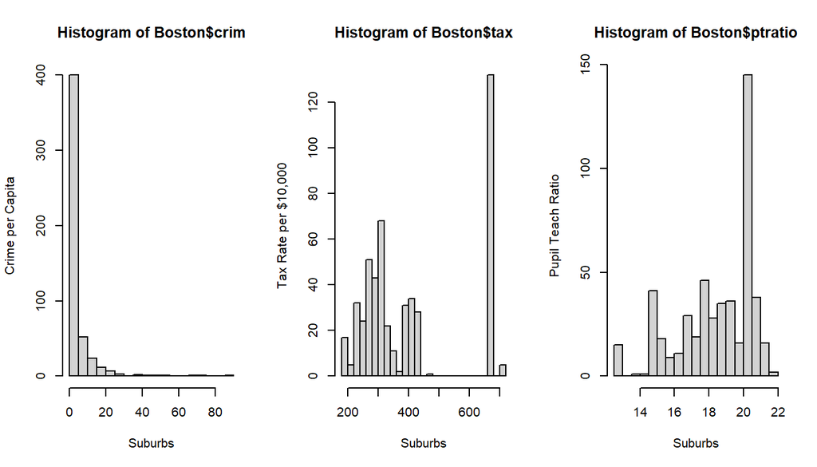

```r
par(mfrow = c(1, 3))
hist(Boston$crim, breaks = 25, xlab = "Suburbs", ylab = "Crime per Capita")
hist(Boston$tax, breaks = 25, xlab = "Suburbs", ylab = "Tax Rate per $10,000")
hist(Boston$ptratio, breaks = 25, xlab = "Suburbs", ylab = "Pupil Teach Ratio")
```

```r
sum(Boston$chas)
```

```
## [1] 35
```

There are 35 suburbs near the Charles River

```r
summary(Boston$ptratio)
```

```
##    Min. 1st Qu.  Median    Mean 3rd Qu.    Max.
##   12.60   17.40   19.05   18.46   20.20   22.00
```

The median for Pupil-Teach Ration is 19.05

```r
lowMed <- Boston[order(Boston$medv),]
lowMed[1,]
```

```
##        crim zn indus chas   nox    rm age    dis rad tax ptratio lstat medv
## 399 38.3518  0  18.1    0 0.693 5.453 100 1.4896  24 666    20.2 30.59    5
```

```r
summary(Boston)
```

```
##       crim                zn             indus            chas
##  Min.   : 0.00632   Min.   :  0.00   Min.   : 0.46   Min.   :0.00000
##  1st Qu.: 0.08205   1st Qu.:  0.00   1st Qu.: 5.19   1st Qu.:0.00000
##  Median : 0.25651   Median :  0.00   Median : 9.69   Median :0.00000
##  Mean   : 3.61352   Mean   : 11.36   Mean   :11.14   Mean   :0.06917
##  3rd Qu.: 3.67708   3rd Qu.: 12.50   3rd Qu.:18.10   3rd Qu.:0.00000
##  Max.   :88.97620   Max.   :100.00   Max.   :27.74   Max.   :1.00000
##       nox               rm             age              dis
##  Min.   :0.3850   Min.   :3.561   Min.   :  2.90   Min.   : 1.130
##  1st Qu.:0.4490   1st Qu.:5.886   1st Qu.: 45.02   1st Qu.: 2.100
##  Median :0.5380   Median :6.208   Median : 77.50   Median : 3.207
##  Mean   :0.5547   Mean   :6.285   Mean   : 68.57   Mean   : 3.795
##  3rd Qu.:0.6240   3rd Qu.:6.623   3rd Qu.: 94.08   3rd Qu.: 5.188
##  Max.   :0.8710   Max.   :8.780   Max.   :100.00   Max.   :12.127
##       rad              tax           ptratio          lstat
##  Min.   : 1.000   Min.   :187.0   Min.   :12.60   Min.   : 1.73
##  1st Qu.: 4.000   1st Qu.:279.0   1st Qu.:17.40   1st Qu.: 6.95
##  Median : 5.000   Median :330.0   Median :19.05   Median :11.36
##  Mean   : 9.549   Mean   :408.2   Mean   :18.46   Mean   :12.65
##  3rd Qu.:24.000   3rd Qu.:666.0   3rd Qu.:20.20   3rd Qu.:16.95
##  Max.   :24.000   Max.   :711.0   Max.   :22.00   Max.   :37.97
##       medv
##  Min.   : 5.00
##  1st Qu.:17.02
##  Median :21.20
##  Mean   :22.53
##  3rd Qu.:25.00
##  Max.   :50.00
```

```r
subset(Boston, Boston$rm > 7)
```

```
##         crim   zn indus chas    nox    rm   age    dis rad tax ptratio lstat
## 3    0.02729  0.0  7.07    0 0.4690 7.185  61.1 4.9671   2 242    17.8  4.03
## 5    0.06905  0.0  2.18    0 0.4580 7.147  54.2 6.0622   3 222    18.7  5.33
## 41   0.03359 75.0  2.95    0 0.4280 7.024  15.8 5.4011   3 252    18.3  1.98
## 56   0.01311 90.0  1.22    0 0.4030 7.249  21.9 8.6966   5 226    17.9  4.81
## 65   0.01951 17.5  1.38    0 0.4161 7.104  59.5 9.2229   3 216    18.6  8.05
## 89   0.05660  0.0  3.41    0 0.4890 7.007  86.3 3.4217   2 270    17.8  5.50
## 90   0.05302  0.0  3.41    0 0.4890 7.079  63.1 3.4145   2 270    17.8  5.70
## 98   0.12083  0.0  2.89    0 0.4450 8.069  76.0 3.4952   2 276    18.0  4.21
## 99   0.08187  0.0  2.89    0 0.4450 7.820  36.9 3.4952   2 276    18.0  3.57
## 100  0.06860  0.0  2.89    0 0.4450 7.416  62.5 3.4952   2 276    18.0  6.19
## 162  1.46336  0.0 19.58    0 0.6050 7.489  90.8 1.9709   5 403    14.7  1.73
## 163  1.83377  0.0 19.58    1 0.6050 7.802  98.2 2.0407   5 403    14.7  1.92
## 164  1.51902  0.0 19.58    1 0.6050 8.375  93.9 2.1620   5 403    14.7  3.32
## 167  2.01019  0.0 19.58    0 0.6050 7.929  96.2 2.0459   5 403    14.7  3.70
```

[output cut: 115 more lines]

```r
summary(subset(Boston, Boston$rm > 7))
```

```
##       crim                zn            indus             chas
##  Min.   : 0.00906   Min.   : 0.00   Min.   : 0.460   Min.   :0.000
##  1st Qu.: 0.04502   1st Qu.: 0.00   1st Qu.: 2.460   1st Qu.:0.000
##  Median : 0.09786   Median :20.00   Median : 3.970   Median :0.000
##  Mean   : 0.97911   Mean   :28.17   Mean   : 5.776   Mean   :0.125
##  3rd Qu.: 0.54289   3rd Qu.:45.00   3rd Qu.: 6.200   3rd Qu.:0.000
##  Max.   :19.60910   Max.   :95.00   Max.   :19.580   Max.   :1.000
##       nox               rm             age              dis
##  Min.   :0.3940   Min.   :7.007   Min.   :  8.40   Min.   :1.202
##  1st Qu.:0.4303   1st Qu.:7.183   1st Qu.: 36.00   1st Qu.:2.445
##  Median :0.4880   Median :7.414   Median : 63.80   Median :3.495
##  Mean   :0.5045   Mean   :7.570   Mean   : 60.64   Mean   :4.200
##  3rd Qu.:0.5825   3rd Qu.:7.859   3rd Qu.: 85.03   3rd Qu.:5.463
##  Max.   :0.7180   Max.   :8.780   Max.   :100.00   Max.   :9.223
##       rad              tax           ptratio          lstat
##  Min.   : 1.000   Min.   :193.0   Min.   :12.60   Min.   : 1.730
##  1st Qu.: 3.000   1st Qu.:244.8   1st Qu.:14.70   1st Qu.: 3.555
##  Median : 5.000   Median :273.0   Median :17.40   Median : 4.775
##  Mean   : 5.984   Mean   :312.2   Mean   :16.26   Mean   : 5.474
##  3rd Qu.: 7.000   3rd Qu.:329.0   3rd Qu.:17.93   3rd Qu.: 6.590
##  Max.   :24.000   Max.   :666.0   Max.   :20.20   Max.   :16.740
##       medv
##  Min.   :15.00
##  1st Qu.:32.98
##  Median :36.45
##  Mean   :38.40
##  3rd Qu.:46.17
##  Max.   :50.00
```

```r
subset(Boston, Boston$rm > 8)
```

```
##        crim zn indus chas    nox    rm  age    dis rad tax ptratio lstat medv
## 98  0.12083  0  2.89    0 0.4450 8.069 76.0 3.4952   2 276    18.0  4.21 38.7
## 164 1.51902  0 19.58    1 0.6050 8.375 93.9 2.1620   5 403    14.7  3.32 50.0
## 205 0.02009 95  2.68    0 0.4161 8.034 31.9 5.1180   4 224    14.7  2.88 50.0
## 225 0.31533  0  6.20    0 0.5040 8.266 78.3 2.8944   8 307    17.4  4.14 44.8
## 226 0.52693  0  6.20    0 0.5040 8.725 83.0 2.8944   8 307    17.4  4.63 50.0
## 227 0.38214  0  6.20    0 0.5040 8.040 86.5 3.2157   8 307    17.4  3.13 37.6
## 233 0.57529  0  6.20    0 0.5070 8.337 73.3 3.8384   8 307    17.4  2.47 41.7
## 234 0.33147  0  6.20    0 0.5070 8.247 70.4 3.6519   8 307    17.4  3.95 48.3
## 254 0.36894 22  5.86    0 0.4310 8.259  8.4 8.9067   7 330    19.1  3.54 42.8
## 258 0.61154 20  3.97    0 0.6470 8.704 86.9 1.8010   5 264    13.0  5.12 50.0
## 263 0.52014 20  3.97    0 0.6470 8.398 91.5 2.2885   5 264    13.0  5.91 48.8
## 268 0.57834 20  3.97    0 0.5750 8.297 67.0 2.4216   5 264    13.0  7.44 50.0
## 365 3.47428  0 18.10    1 0.7180 8.780 82.9 1.9047  24 666    20.2  5.29 21.9
```

```r
summary(subset(Boston, Boston$rm > 8))
```

```
##       crim               zn            indus             chas
##  Min.   :0.02009   Min.   : 0.00   Min.   : 2.680   Min.   :0.0000
##  1st Qu.:0.33147   1st Qu.: 0.00   1st Qu.: 3.970   1st Qu.:0.0000
##  Median :0.52014   Median : 0.00   Median : 6.200   Median :0.0000
##  Mean   :0.71880   Mean   :13.62   Mean   : 7.078   Mean   :0.1538
##  3rd Qu.:0.57834   3rd Qu.:20.00   3rd Qu.: 6.200   3rd Qu.:0.0000
##  Max.   :3.47428   Max.   :95.00   Max.   :19.580   Max.   :1.0000
##       nox               rm             age             dis
##  Min.   :0.4161   Min.   :8.034   Min.   : 8.40   Min.   :1.801
##  1st Qu.:0.5040   1st Qu.:8.247   1st Qu.:70.40   1st Qu.:2.288
##  Median :0.5070   Median :8.297   Median :78.30   Median :2.894
##  Mean   :0.5392   Mean   :8.349   Mean   :71.54   Mean   :3.430
##  3rd Qu.:0.6050   3rd Qu.:8.398   3rd Qu.:86.50   3rd Qu.:3.652
##  Max.   :0.7180   Max.   :8.780   Max.   :93.90   Max.   :8.907
##       rad              tax           ptratio          lstat           medv
##  Min.   : 2.000   Min.   :224.0   Min.   :13.00   Min.   :2.47   Min.   :21.9
##  1st Qu.: 5.000   1st Qu.:264.0   1st Qu.:14.70   1st Qu.:3.32   1st Qu.:41.7
##  Median : 7.000   Median :307.0   Median :17.40   Median :4.14   Median :48.3
##  Mean   : 7.462   Mean   :325.1   Mean   :16.36   Mean   :4.31   Mean   :44.2
##  3rd Qu.: 8.000   3rd Qu.:307.0   3rd Qu.:17.40   3rd Qu.:5.12   3rd Qu.:50.0
##  Max.   :24.000   Max.   :666.0   Max.   :20.20   Max.   :7.44   Max.   :50.0
```